# Hyne Log Metrics

JH

# 1 Background

A set of log metrics were computed and inserted in the database at the time logs were selected (original untrimmed length) and again at the time they were sawn. At sawing, metrics for some logs were missed as the logs were processed before the selection app was set running.

Bin files were collected for all selected logs from ROY scanner (see KEEPBINFILES)

Bin files were collected from all true shape scanners at time of sawing:

ORI - log scan before turner and debarker. not necessarily in same sequence as sawn ROY - log scan before trideck ELI - log scan after trideck HSS - cant scan

Shape scans at Hyne are all SE first, except for the ORI scanner (well duh), and some logs on the main chain (ML thinks only small diameter logs not worth turning around)

Code that flipped logs that appeared to be presented LE first was enabled during the selection phase, but not the sawing phase.

# 2 Goal

- Compute metrics for logs not processed at sawing time.
- Compute new metrics for all logs.
- How stable are metrics with respect to scanner hardware/calibration?
- Evaluate feasibility of combining all scan data for a particular log. Would doing this result in a ‘better’ representation?

# 3 Analysis

```r
library(lattice)

# 1. metrics in the db already
library(RODBC)
ch = odbcConnect('Hyne',uid='sa',pwd="password12")
DB = sqlQuery(ch, "select *, seq=ID, scanner='ROY', source='db' from logs where SWILogNumber is not null")
DB$trimstate[DB$DateAndTime<as.POSIXct('2014-08-31')] = 'untrimmed'
DB$trimstate[DB$DateAndTime>as.POSIXct('2014-08-31')] = 'trimmed'
DB$trimstate = factor(DB$trimstate, levels=c('untrimmed','trimmed'), ordered=TRUE)

# 2. freshly computed results from logs.csv file
CSV = read.csv('/home/harrinjj/G/Projects/Hyne/USNR/logs.csv')
re = "(?:.*USNR Image Files/)([^/]+)/(?:tri_cam)?(.+)\\.bin"
CSV$scanner = gsub(re,"\\1",CSV$binfn,perl=TRUE)
CSV$bindir = CSV$scanner
CSV$seq = as.numeric(gsub(re,"\\2",CSV$binfn,perl=TRUE))
swi.log.numbers.in.sawing.order = sqlQuery(ch, "select SWILogNumber as l from logs where SWILogNumber is not null and DateAndTime>'2014-08-31' order by DateAndTime")$l
# deal with the 8 non-trial logs that were on the deck
ii = CSV$scanner%in%c('HSS','ELI')
CSV$seq[ii] = CSV$seq[ii] - 8
#ii=CSV$scanner%in%c('ORI','ELI','HSS')&CSV$seq>0
ii=CSV$scanner%in%c('ELI','HSS')&CSV$seq>0
CSV$SWILogNumber[ii] = swi.log.numbers.in.sawing.order[CSV$seq[ii]]
CSV$source='binfiles'
#library(hash)
H = sqlQuery(ch, "select ID, SWILogNumber from logs where SWILogNumber is not null")#" and DateAndTime<'2014-08-31'")
#H = hash(keys=as.numeric(H$ID), values=as.numeric(H$SWILogNumber))
HH=c()
HH[H$ID]=H$SWILogNumber
for (ID in unique(CSV$seq[CSV$seq>500])) {
  if (!is.na(HH[ID])) {
    CSV$SWILogNumber[CSV$seq==ID] = HH[ID]
    }
}
# old way: CSV$SWILogNumber[CSV$seq=='119902'] = DB$SWILogNumber[DB$ID=='119902']
#CSV$SWILogNumber[CSV$seq=='119808'] = DB$SWILogNumber[DB$ID=='119808']
#summary(CSV$SWILogNumber)
#CSV$binfn[is.na(CSV$SWILogNumber)]

# now merge DB and CSV
# drop stuff other than log metrics and strip the leading 'm_'
db.cols=c(c("SWILogNumber","scanner","trimstate","source","seq"),grep('m_',names(DB),perl=TRUE,value=TRUE))
DB2=DB[,db.cols]
names(DB2)<-gsub('m_','',db.cols)

rbind.all.columns <- function(x, y) {
    x.diff <- setdiff(colnames(x), colnames(y))
    y.diff <- setdiff(colnames(y), colnames(x))
    x[, c(as.character(y.diff))] <- NA
    y[, c(as.character(x.diff))] <- NA
    return(rbind(x, y))
}
L = rbind.all.columns(DB2,CSV)
L$SWILogNumber = factor(L$SWILogNumber, ordered=TRUE)
L$scanner[L$scanner=='KEEPBINFILES'] = 'ROY'
L$scanner = factor(L$scanner, levels=c('ORI','ROY','ELI','HSS'), ordered=TRUE)
L = L[!is.na(L$SWILogNumber),] # drop non-trial logs
L = L[L$scanner!='HSS',] # drop cant scans

log.metrics = setdiff(names(L),c("SWILogNumber","scanner","trimstate","source","seq","fail","origOrient","nslices","dzmax","dzmin","binfn","bindir"))
```

*Logs with unusual numbers of shape metric sets?*

```r
t=table(L$SWILogNumber)
t[t!=5]
```

```
##
## 140 150
##   6   6
```

```r
L[L$SWILogNumber==141,c('binfn','source')]
```

```
##                                                                                   binfn
## 37                                                                                 <NA>
## 241                                                                                <NA>
## 364 /media/Q/SWI/LogsAndStems/Hyne_2014/Aug2014/USNR Image Files/KEEPBINFILES/91201.bin
## 487 /media/Q/SWI/LogsAndStems/Hyne_2014/Aug2014/USNR Image Files/KEEPBINFILES/91201.bin
## 648     /media/Q/SWI/LogsAndStems/Hyne_2014/Aug2014/USNR Image Files/ELI/tri_cam126.bin
##       source
## 37        db
## 241       db
## 364 binfiles
## 487 binfiles
## 648 binfiles
```

```r
L[L$SWILogNumber==140,c('binfn','source')]
```

```
##                                                                                   binfn
## 38                                                                                 <NA>
## 227                                                                                <NA>
## 350 /media/Q/SWI/LogsAndStems/Hyne_2014/Aug2014/USNR Image Files/KEEPBINFILES/91203.bin
## 473 /media/Q/SWI/LogsAndStems/Hyne_2014/Aug2014/USNR Image Files/KEEPBINFILES/91203.bin
## 617         /media/Q/SWI/LogsAndStems/Hyne_2014/Aug2014/USNR Image Files/ROY/119902.bin
## 633     /media/Q/SWI/LogsAndStems/Hyne_2014/Aug2014/USNR Image Files/ELI/tri_cam112.bin
##       source
## 38        db
## 227       db
## 350 binfiles
## 473 binfiles
## 617 binfiles
## 633 binfiles
```

```r
L[L$SWILogNumber==150,c('binfn','source')]
```

```
##                                                                                   binfn
## 57                                                                                 <NA>
## 133                                                                                <NA>
## 256 /media/Q/SWI/LogsAndStems/Hyne_2014/Aug2014/USNR Image Files/KEEPBINFILES/92583.bin
## 379 /media/Q/SWI/LogsAndStems/Hyne_2014/Aug2014/USNR Image Files/KEEPBINFILES/92583.bin
## 616         /media/Q/SWI/LogsAndStems/Hyne_2014/Aug2014/USNR Image Files/ROY/119808.bin
## 659      /media/Q/SWI/LogsAndStems/Hyne_2014/Aug2014/USNR Image Files/ELI/tri_cam18.bin
##       source
## 57        db
## 133       db
## 256 binfiles
## 379 binfiles
## 616 binfiles
## 659 binfiles
```

ROY scanner binfiles for logs 140 and 150 were not lost.

The ELI scanner binfile for log 141 (ELI/tri_cam126.bin) has issues.

*Numbers of metric sets?*

```r
table(L$trimstate, L$scanner, L$source)
```

```
## , ,  = db
##
##
##             ORI ROY ELI HSS
##   untrimmed   0 123   0   0
##   trimmed     0 123   0   0
##
## , ,  = binfiles
##
##
##             ORI ROY ELI HSS
##   untrimmed   0 123   0   0
##   trimmed     0 125 123   0
```

*Do the two recomputed sets of ROY metrics match those computed at sawing time?*

```r
cols = c(c('scanner','source','trimstate','bindir','seq'),log.metrics)
t(L[L$SWILogNumber==140, cols])
```

```
##                        38             227            350
## scanner                "ROY"          "ROY"          "ROY"
## source                 "db"           "db"           "binfiles"
## trimstate              "untrimmed"    "trimmed"      "untrimmed"
## bindir                 NA             NA             "KEEPBINFILES"
## seq                    " 91203"       "119902"       " 91203"
## length                 "6076.139"     "4826.000"     "6076.139"
## volume                 "0.4732999"    "0.3491301"    "0.4732999"
## led                    "397.1552"     "327.3679"     "397.1552"
## sed                    "302.1312"     "301.8128"     "302.1312"
## a0                     "296.6347"     "291.5422"     "296.6347"
## a1                     "-18.61085"    " 12.85245"    "-18.61085"
## a2                     "91.17738"     "28.88385"     "91.17738"
## taper                  "11.942869"    " 8.648218"    "11.942869"
## waist                  "0.6174072"    "0.3100419"    "0.6174072"
## ovality                "9.118804e-05" "5.305785e-05" "9.118804e-05"
## whorliness             "1.1883257"    "1.0611178"    "1.1883257"
## sweep1                 "0.6748855"    "0.6149826"    "0.6748855"
## sweep2                 "0.2116119"    "0.2390790"    "0.2116119"
## gaxis_maxdev           NA             NA             "24.91641"
## gaxis_volume           NA             NA             "1182793.0"
## sd_xsectnarea_butthalf NA             NA             "12484.380"
## wobble                 NA             NA             "3.735551"
## wobble_x               NA             NA             "6.307136"
## wobble_y               NA             NA             "6.238595"
##                        473            617            633
## scanner                "ROY"          "ROY"          "ELI"
## source                 "binfiles"     "binfiles"     "binfiles"
## trimstate              "trimmed"      "trimmed"      "trimmed"
## bindir                 "KEEPBINFILES" "ROY"          "ELI"
## seq                    " 91203"       "119902"       "   104"
## length                 "4907.644"     "4826.000"     "4572.000"
## volume                 "0.3430806"    "0.3491301"    "0.3186620"
## led                    "332.5861"     "327.3679"     "328.7093"
## sed                    "302.1312"     "301.8128"     "284.4171"
## a0                     "292.8333"     "291.5422"     "284.5500"
## a1                     "  4.26992"    " 12.85245"    " 18.90512"
## a2                     "40.18010"     "28.88385"     "21.28797"
## taper                  " 9.057304"    " 8.648218"    " 8.791140"
## waist                  "0.4170661"    "0.3100419"    "0.2546021"
## ovality                "1.445811e-05" "5.305785e-05" "5.458508e-05"
## whorliness             "1.1509781"    "1.0611178"    "0.9380907"
## sweep1                 "0.9134273"    "0.6149826"    "0.9181781"
## sweep2                 "0.1974636"    "0.2390790"    "0.2364718"
## gaxis_maxdev           "21.99987"     "14.32311"     "19.19285"
## gaxis_volume           " 513483.2"    " 384893.8"    " 433747.9"
## sd_xsectnarea_butthalf " 7424.744"    " 7006.620"    " 7013.027"
## wobble                 "3.060341"     "2.227319"     "2.280054"
## wobble_x               "4.807097"     "4.290384"     "5.076679"
## wobble_y               "5.769047"     "4.837054"     "4.598366"
```

```r
t(L[L$SWILogNumber==150, cols])
```

```
##                        57             133            256
## scanner                "ROY"          "ROY"          "ROY"
## source                 "db"           "db"           "binfiles"
## trimstate              "untrimmed"    "trimmed"      "untrimmed"
## bindir                 NA             NA             "KEEPBINFILES"
## seq                    " 92583"       "119808"       " 92583"
## length                 "4724.400"     "4724.400"     "4724.400"
## volume                 "0.9785541"    "0.9746568"    "0.9785541"
## led                    "547.3299"     "542.7364"     "547.3299"
## sed                    "510.3448"     "508.4683"     "510.3448"
## a0                     "499.5402"     "498.2023"     "499.5402"
## a1                     "22.85488"     "28.98543"     "22.85488"
## a2                     "30.34987"     "22.05943"     "30.34987"
## taper                  "11.26169"     "10.80452"     "11.26169"
## waist                  "0.3399409"    "0.2470820"    "0.3399409"
## ovality                "0.0003671312" "0.0005038186" "0.0003671312"
## whorliness             "1.125857"     "1.019570"     "1.125857"
## sweep1                 "2.043897"     "1.787210"     "2.043897"
## sweep2                 "0.5922525"    "0.6586372"    "0.5922525"
## gaxis_maxdev           NA             NA             "45.61970"
## gaxis_volume           NA             NA             "2849045"
## sd_xsectnarea_butthalf NA             NA             "14339.96"
## wobble                 NA             NA             "6.342098"
## wobble_x               NA             NA             "12.46894"
## wobble_y               NA             NA             "11.21478"
##                        379            616            659
## scanner                "ROY"          "ROY"          "ELI"
## source                 "binfiles"     "binfiles"     "binfiles"
## trimstate              "trimmed"      "trimmed"      "trimmed"
## bindir                 "KEEPBINFILES" "ROY"          "ELI"
## seq                    " 92583"       "119808"       "    10"
## length                 "4856.572"     "4724.400"     "4857.212"
## volume                 "0.9542162"    "0.9746568"    "0.9728274"
## led                    "557.1632"     "542.7364"     "534.6488"
## sed                    "510.3448"     "508.4683"     "503.1886"
## a0                     "499.4897"     "498.2023"     "492.0899"
## a1                     "18.00893"     "28.98543"     "16.54381"
## a2                     "36.43158"     "22.05943"     "32.95395"
## taper                  "11.20966"     "10.80452"     "10.19057"
## waist                  "0.3861521"    "0.2470820"    "0.3491993"
## ovality                "0.0003639022" "0.0005038186" "0.0003315628"
## whorliness             "1.143183"     "1.019570"     "0.892767"
## sweep1                 "2.191713"     "1.787210"     "1.816740"
## sweep2                 "0.4620330"    "0.6586372"    "0.5351630"
## gaxis_maxdev           "51.69439"     "39.89044"     "42.86146"
## gaxis_volume           "2735936"      "2770480"      "2628537"
## sd_xsectnarea_butthalf "14144.61"     "13459.59"     "12639.84"
## wobble                 "6.251340"     "5.232295"     "5.510685"
## wobble_x               "12.34018"     "12.45737"     "10.76491"
## wobble_y               "10.81060"     "11.70114"     "12.18194"
```

Conclusions:

1. current code produces exactly same results as the code used to populate the database

## 3.1 Metric Comparison

*How do log metrics from the different scanners and processing paths compare?*

```r
library(reshape2)
# flipped logs
flipped = c(208,207,203,210,147,202,149,155,168,200,209,212,196,199,127,158,169,181,177,166,151,182,179,101,178,106,175,124,172,104,187,117,142,114,113)
myplot = function(trimstate,prop) {
  LL = dcast(L[L$trimstate==trimstate&!is.na(L[,prop]),], 'SWILogNumber ~ scanner + source', mean, value.var=prop)
  try(print(splom(LL[,2:ncol(LL)], group=LL$SWILogNumber%in%flipped, main=prop)), silent=FALSE)
  return(LL)
}
```

### 3.1.1 Untrimmed

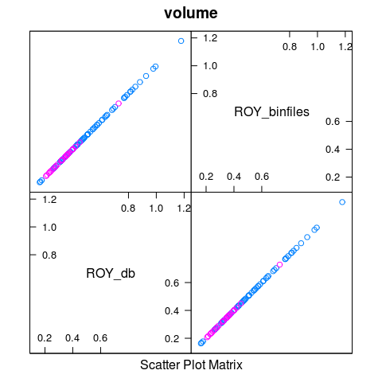

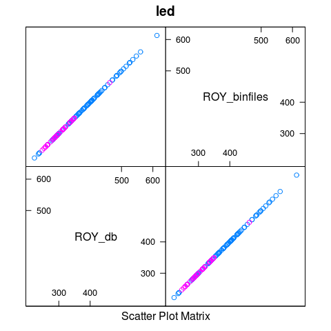

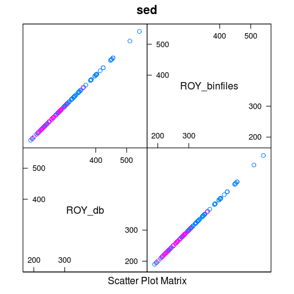

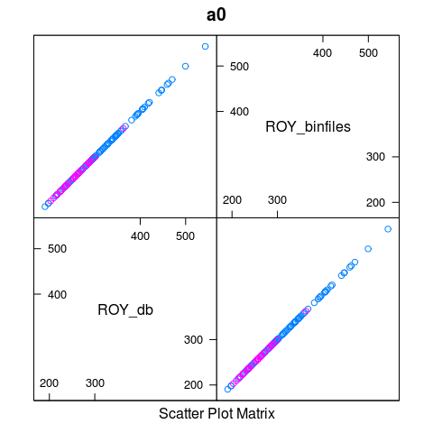

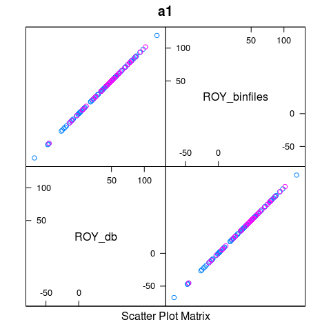

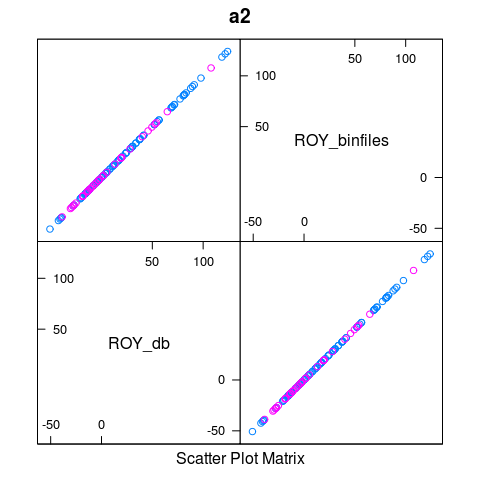

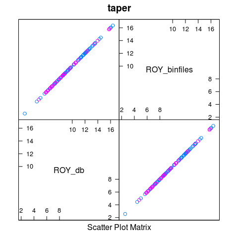

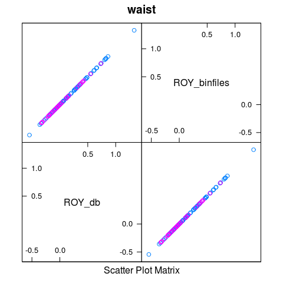

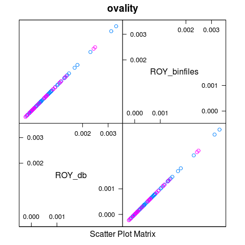

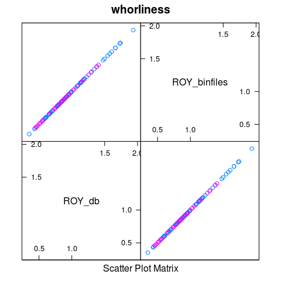

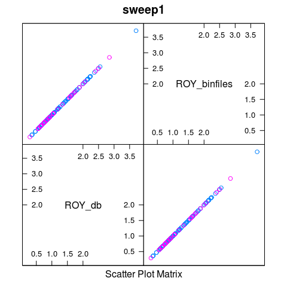

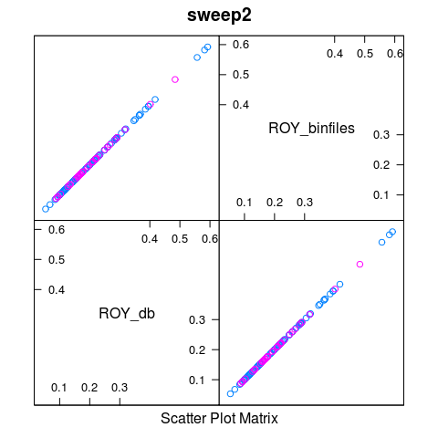

```r
for (p in log.metrics) {try(LL<-myplot('untrimmed',p), silent=FALSE)}
```

### 3.1.2 Trimmed:

- ROY_db - metrics computed at sawing time based on binfiles of trimmed logs and stored in the db.
- ELI_binfiles - binfiles collected at time of sawing (i.e. trimmed logs) metrics computed later
- ROY_binfiles - metrics computed from binfiles collected at selection time (i.e. untrimmed logs) but trimmed *in silico*

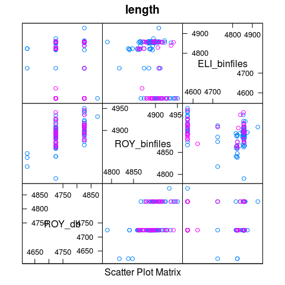

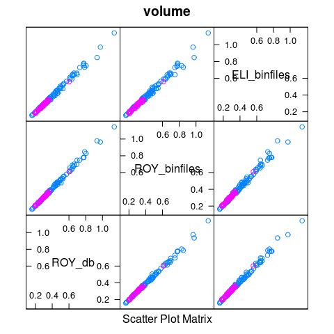

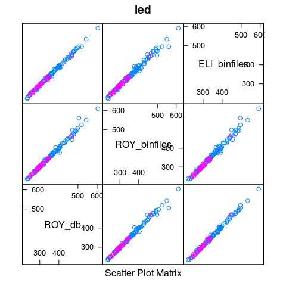

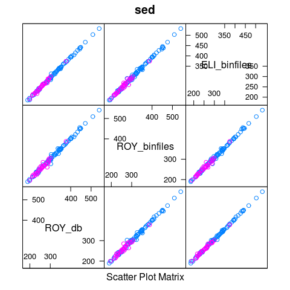

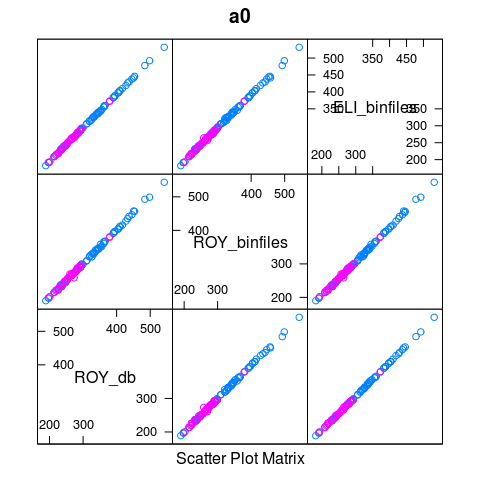

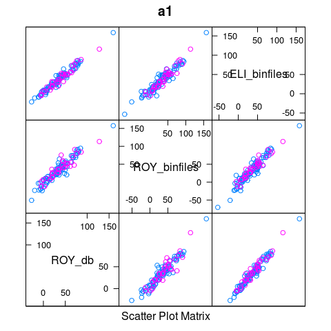

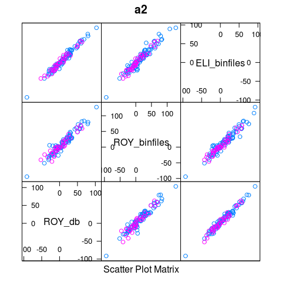

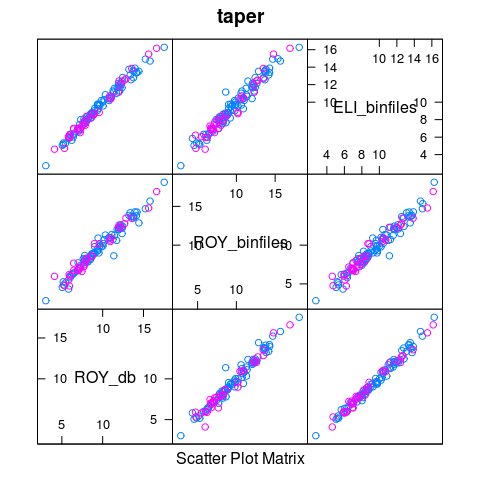

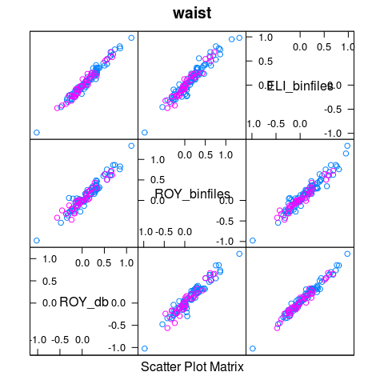

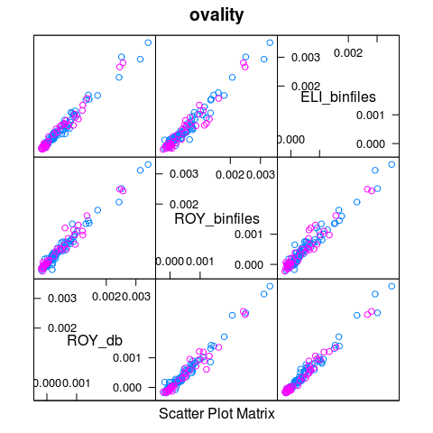

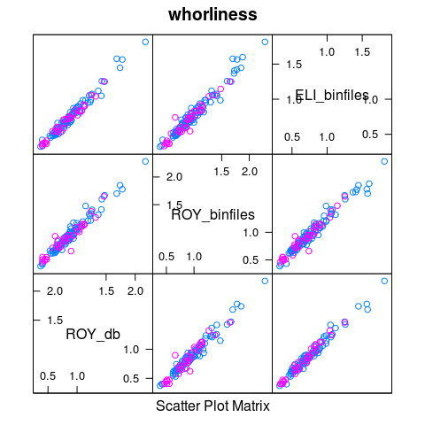

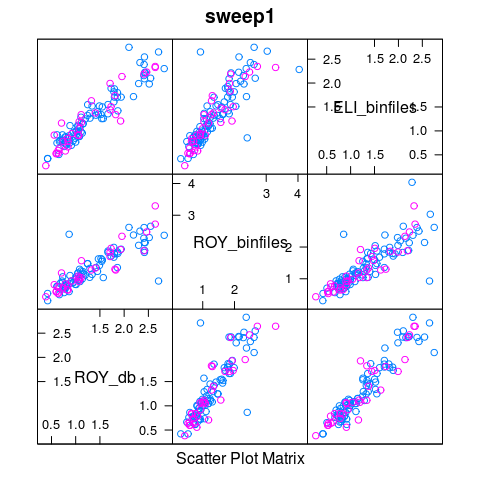

[7 more figures not shown]

```r
for (p in log.metrics) {try(LL<-myplot('trimmed',p), silent=FALSE)}
```